# Tugas Pertemuan 6

Muhammad Fauzan Nur Rasendriya (G1401231108)

10 October 2025

# Library

```r
install_load <- function (package1, ...){
   packages <- c(package1, ...)
   for(package in packages){
       if(package %in% rownames(installed.packages())){
         do.call('library', list(package))
       }
       else{
          install.packages(package)
          do.call("library", list(package))
       }
   }
}

install_load("knitr","showtext","rio","dplyr","tsibble","ggplot2","MASS","lattice","tseries","forecast","TSA")

opts_knit$set(root.dir = normalizePath("./"))

font_add_google("Lato", "lato")
showtext_auto()
```

# Data

## Impor Data

```r
data <- import("https://raw.githubusercontent.com/fauzanrasendriya/MPDW/main/Pertemuan%205/dataudarajkt.csv")

head(data)
```

|  | tanggal | stasiun | pm25 | pm10 | so2 | co | o3 | no2 | max | critical | categori |
| --- | --- | --- | --- | --- | --- | --- | --- | --- | --- | --- | --- |
| 1 | 2023-10-18 | DKI1 (Bunderan HI) | 108 | 64 | 50 | 9 | 29 | 34 | 108 | PM25 | TIDAK SEHAT |
| 2 | 2023-10-19 | DKI1 (Bunderan HI) | 93 | 65 | 51 | 9 | 25 | 30 | 93 | PM25 | SEDANG |
| 3 | 2023-10-20 | DKI1 (Bunderan HI) | 78 | 62 | 50 | 6 | 29 | 23 | 78 | PM25 | SEDANG |
| 4 | 2023-10-21 | DKI1 (Bunderan HI) | 88 | 63 | 49 | 6 | 24 | 33 | 88 | PM25 | SEDANG |
| 5 | 2023-10-22 | DKI1 (Bunderan HI) | 91 | 60 | 47 | 4 | 37 | 25 | 91 | PM25 | SEDANG |
| 6 | 2023-10-23 | DKI1 (Bunderan HI) | 86 | 62 | 48 | 6 | 37 | 27 | 86 | PM25 | SEDANG |

Data yang digunakan merupakan data kualitas udara dengan peubah yang diamati adalah PM10, yaitu konsentrasi partikel dengan diameter 10 mikrometer atau lebih kecil. Dataset aslinya mencakup periode yang lebih panjang, namun untuk analisis ini diambil 125 observasi dari tanggal 24 Juni 2024 hingga 28 Oktober 2024. Data ini diperoleh dari Kaggle.

# Eksplorasi Data

```r
names(data)
```

```
##  [1] "tanggal"  "stasiun"  "pm25"     "pm10"     "so2"      "co"
##  [7] "o3"       "no2"      "max"      "critical" "categori"
```

```r
# -----------------------------
# Pilih peubah target di sini
# -----------------------------
target_col <- "pm10"
```

```r
# filter baris 251 sampai 375
subset_data <- data[251:375, c("tanggal", "stasiun", target_col)]

# lihat data
head(subset_data)
```

|  | tanggal | stasiun | pm10 |
| --- | --- | --- | --- |
| 251 | 2024-06-24 | DKI1 (Bunderan HI) | 57 |
| 252 | 2024-06-25 | DKI1 (Bunderan HI) | 58 |
| 253 | 2024-06-26 | DKI1 (Bunderan HI) | 51 |
| 254 | 2024-06-27 | DKI1 (Bunderan HI) | 56 |
| 255 | 2024-06-28 | DKI1 (Bunderan HI) | 53 |
| 256 | 2024-06-29 | DKI1 (Bunderan HI) | 52 |

## Plot *Time Series*

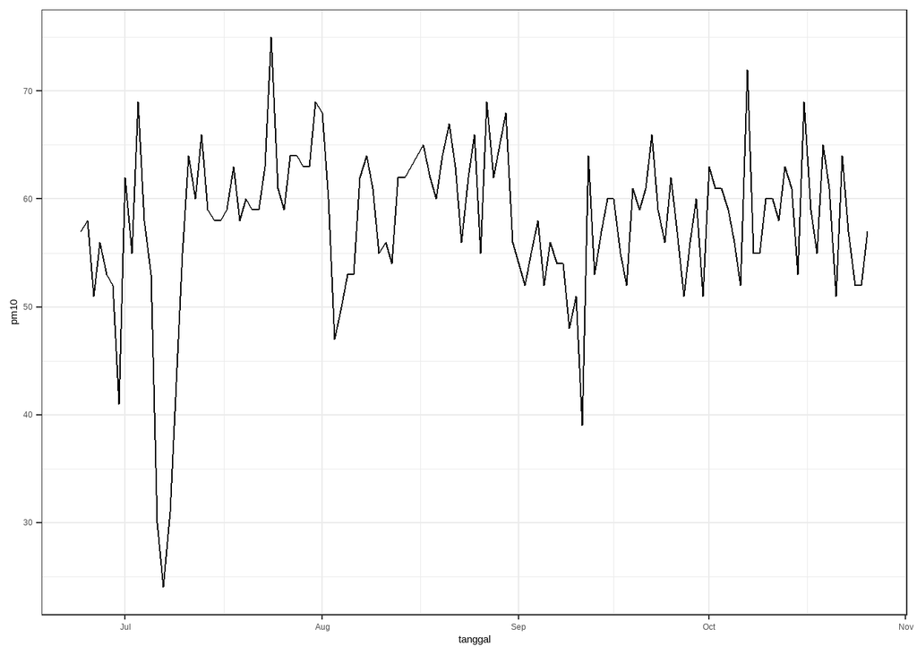

```r
plot_subset_data <- subset_data |>
  as_tsibble(index = tanggal) |>
  ggplot(aes(x = tanggal, y = subset_data[[target_col]])) +
  geom_line() +
  theme_bw() +
  xlab("tanggal") +
  ylab(target_col)

plot_subset_data
```

Berdasarkan plot *time series*, data terlihat stasioner dalam rataan karena tidak menunjukkan adanya tren maupun pola musiman. Namun, data belum stasioner dalam ragam, yang ditunjukkan oleh adanya perbedaan besar-kecilnya fluktuasi pada plot.

```r
mean(subset_data[[target_col]])
```

```
## [1] 57.84
```

## Plot *Density*

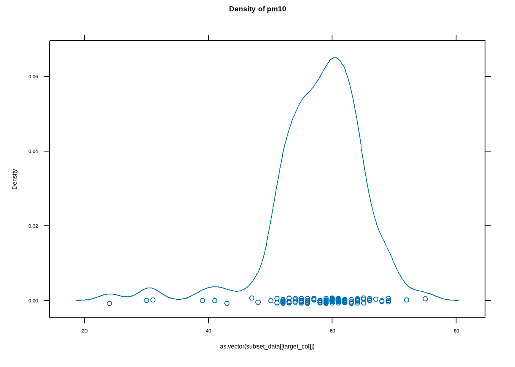

```r
lattice::densityplot(as.vector(subset_data[[target_col]]), main = paste("Density of", target_col))
```

Plot *density* di atas menunjukkan bahwa data stasioner dalam rataan, ditandai dengan data yang menyebar di nilai tengahnya (57) dan tidak stasioner dalam ragam, ditandai dengan data berfluktuasi pada rentang yang berbeda sepanjang waktu.

## Uji ADF

```r
tseries::adf.test(subset_data[[target_col]])
```

```
##
##  Augmented Dickey-Fuller Test
##
## data:  subset_data[[target_col]]
## Dickey-Fuller = -4.8018, Lag order = 4, p-value = 0.01
## alternative hypothesis: stationary
```

$H_0$ : Data tidak stasioner dalam rataan

$H_1$ : Data stasioner dalam rataan

## Plot Box-Cox

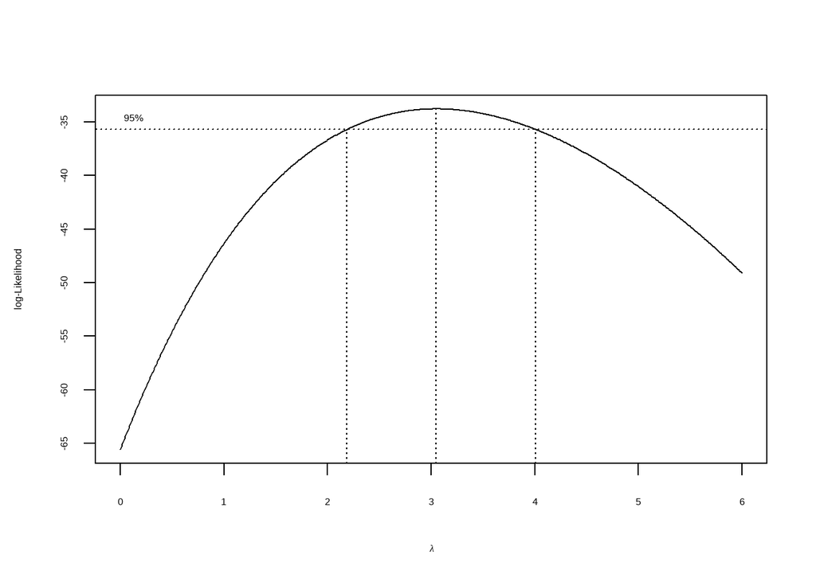

```r
index <- seq_len(nrow(subset_data))

# Box-Cox
bc1 <- boxcox(
  subset_data[[target_col]] ~ index,
  lambda = seq(0, 6, by = 0.01)
)
```

```r
# Nilai lambda optimum
lambda_bc1 <- bc1$x[which.max(bc1$y)]
lambda_bc1
```

```
## [1] 3.05
```

```r
# Selang kepercayaan 95% untuk lambda
ci_lambda1 <- bc1$x[bc1$y > max(bc1$y) - 0.5 * qchisq(0.95, 1)]

# Batas bawah dan batas atas
ci_lower1 <- min(ci_lambda1)
ci_upper1 <- max(ci_lambda1)

c(Batas_Bawah = ci_lower1, Batas_Atas = ci_upper1)
```

```
## Batas_Bawah  Batas_Atas
##        2.19        4.00
```

Hasil uji Box–Cox menunjukkan bahwa nilai λ optimum adalah 3.05 dengan interval kepercayaan 95% sebesar (2.19–4.00). Karena selang tersebut tidak memuat nilai λ = 1, maka dapat disimpulkan bahwa data tidak stasioner dalam ragam sehingga diperlukan transformasi.

# Penanganan Stasioneritas

## Transformasi Box–Cox

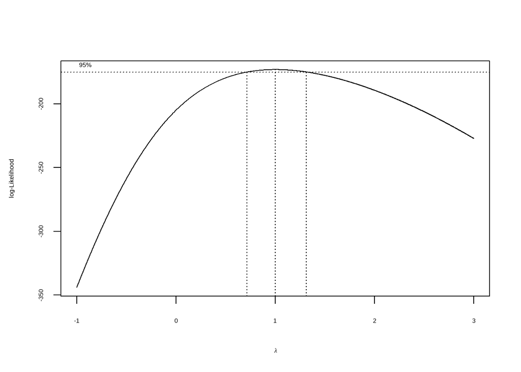

```r
# Transformasi Box-Cox dengan lambda ~ 3.05
y_bc2 <- subset_data[[target_col]]^lambda_bc1

# Uji Box-Cox
bc2 <- boxcox(
  y_bc2 ~ index,
  lambda = seq(-1, 3, by = 0.001)
)
```

```r
# Nilai lambda optimum (dibulatkan)
lambda_bc2 <- bc2$x[which.max(bc2$y)]
lambda_bc2
```

```
## [1] 1
```

```r
# Selang kepercayaan 95% untuk lambda
ci_lambda2 <- bc2$x[bc2$y > max(bc2$y) - 0.5 * qchisq(0.95, 1)]

# Batas bawah dan batas atas
ci_lower2 <- min(ci_lambda2)
ci_upper2 <- max(ci_lambda2)

c(Batas_Bawah = ci_lower2, Batas_Atas = ci_upper2)
```

```
## Batas_Bawah  Batas_Atas
##       0.716       1.314
```

Hasil uji Box–Cox menunjukkan bahwa nilai λ optimum adalah 1 dengan interval kepercayaan 95% sebesar (0.716–1.314). Karena selang tersebut memuat nilai λ = 1, maka dapat disimpulkan bahwa data stasioner dalam ragam.

# Perbandingan Plot Sebelum Vs Sesudah Box-Cox

## Plot *Time Series*

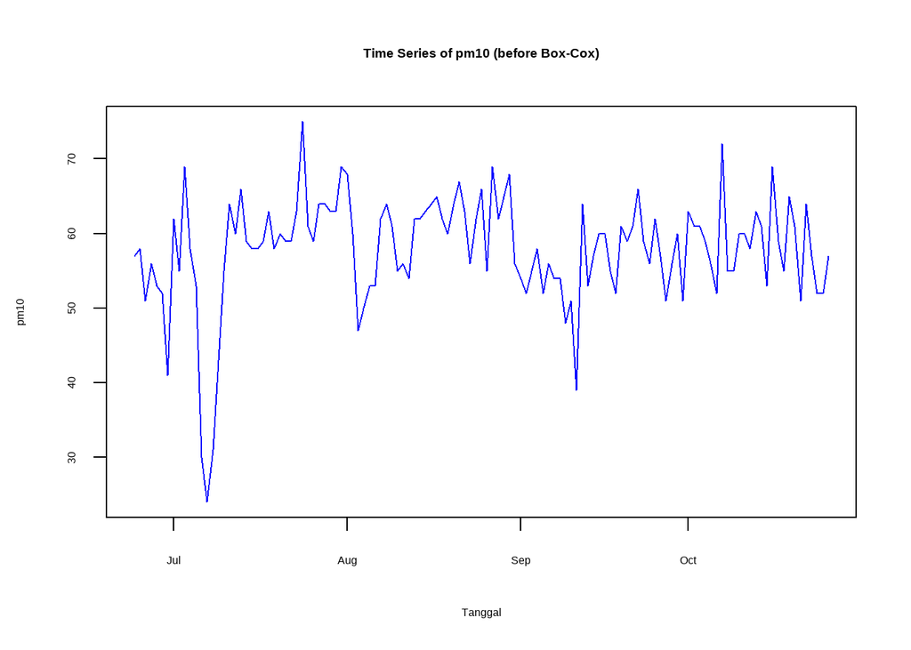

```r
# Time Series sebelum Box–Cox
plot(subset_data$tanggal, subset_data[[target_col]], type="l",
     main=paste("Time Series of", target_col, "(before Box-Cox)"),
     xlab="Tanggal", ylab=target_col, col="blue")
```

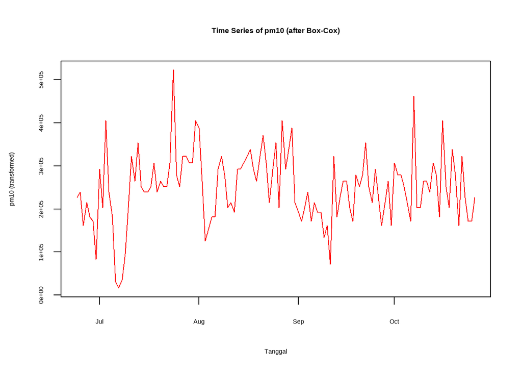

```r
# Time Series sesudah Box–Cox
plot(subset_data$tanggal, y_bc2, type="l",
     main=paste("Time Series of", target_col, "(after Box-Cox)"),
     xlab="Tanggal", ylab=paste(target_col, "(transformed)"), col="red")
```

Berdasarkan plot *time series*, data terlihat stasioner dalam rataan karena tidak menunjukkan adanya tren maupun pola musiman dan data juga terlihat stasioner dalam ragam, ditandai dengan data berfluktuasi pada rentang yang relatif sama sepanjang waktu.

```r
mean(subset_data[[target_col]])
```

```
## [1] 57.84
```

## Plot *Density*

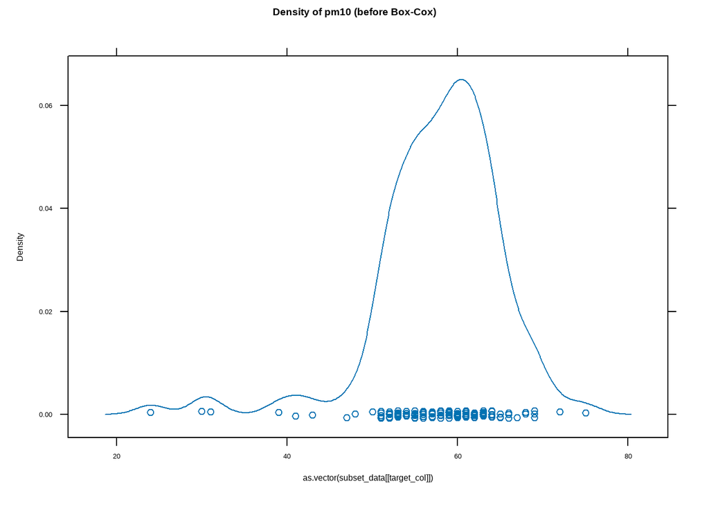

```r
# Density sebelum Box–Cox
lattice::densityplot(as.vector(subset_data[[target_col]]),
                     main = paste("Density of", target_col, "(before Box-Cox)"))
```

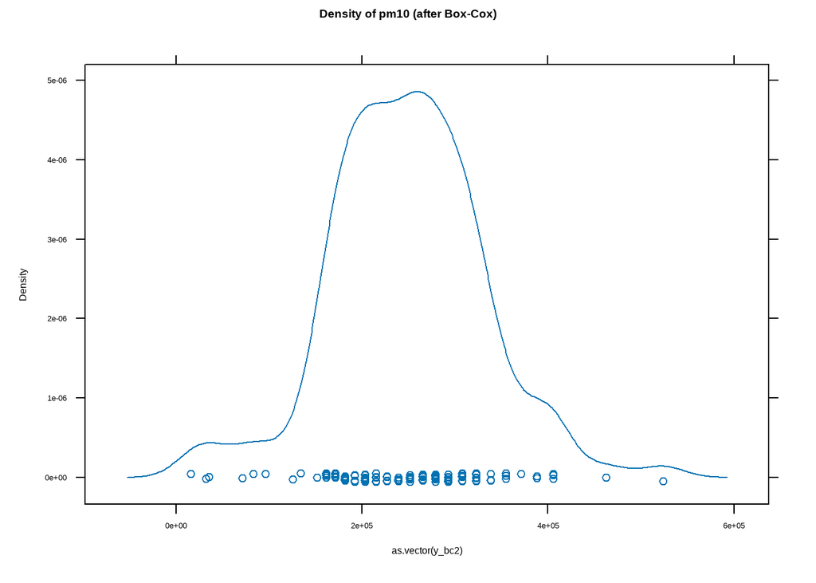

```r
# Density sesudah Box–Cox
lattice::densityplot(as.vector(y_bc2),
                     main = paste("Density of", target_col, "(after Box-Cox)"))
```

# Pemodelan ARIMA

## Split Data

```r
n <- length(y_bc2)
n_train <- round(0.8 * n)

train <- y_bc2[1:n_train]
test  <- y_bc2[(n_train+1):n]
```

## Identifikasi Model

### Plot ACF dan PACF

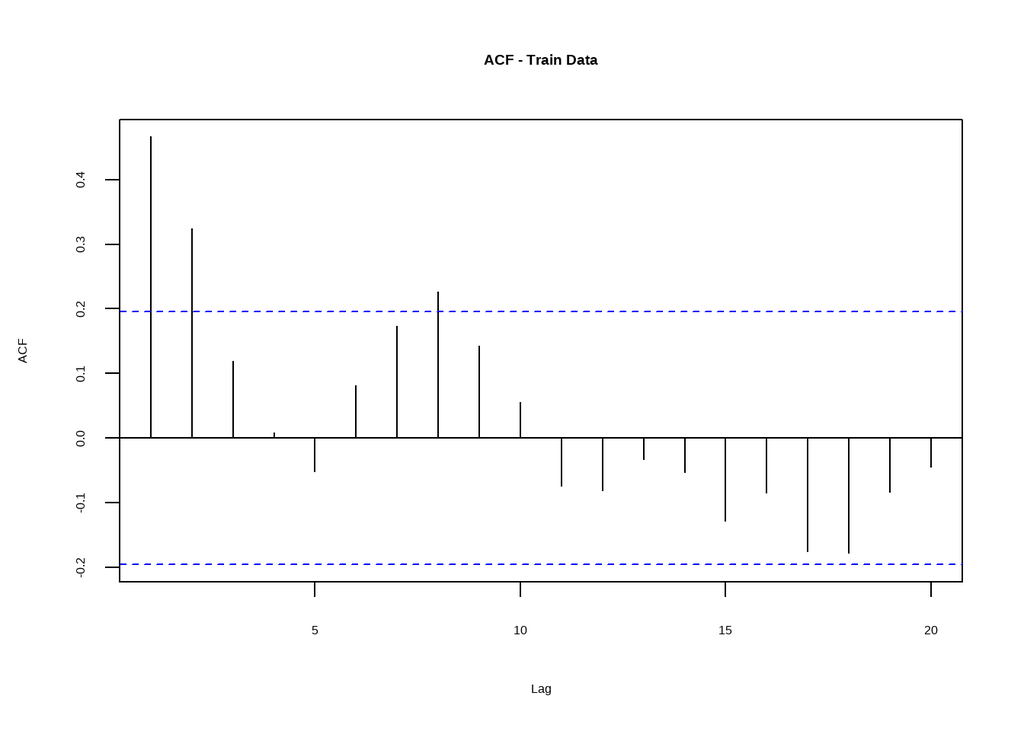

```r
acf(train, main="ACF - Train Data")
```

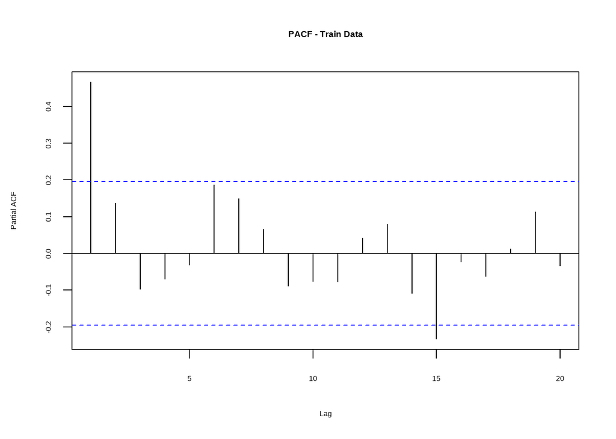

```r
pacf(train, main="PACF - Train Data")
```

Dari ACF:

- Lag 1–2 signifikan → ada autokorelasi pada lag awal.
- Setelah itu, nilai ACF menurun perlahan (tailing off). → Ciri khas adanya komponen AR (Autoregressive).

Dari PACF:

- Lag 1 signifikan besar, setelah itu sebagian besar tidak signifikan (cut-off). → Ciri khas model AR(1) (p = 1).

Kesimpulan gabungan ACF & PACF:

- ACF tailing off + PACF cut-off di lag 1 → indikasi kuat model kandidat adalah ARIMA(1,0,0) atau model dengan komponen AR dominan.

### Plot EACF

```r
eacf(train)
```

```
## AR/MA
##   0 1 2 3 4 5 6 7 8 9 10 11 12 13
## 0 x x o o o o o x o o o  o  o  o
## 1 x o o o o o o o o o o  o  o  o
## 2 x x o o o o o o o o o  o  o  o
## 3 x o o o o o o o o o o  o  o  o
## 4 x o x o o o o o o o o  o  o  o
## 5 o x x x o o o o o o o  o  o  o
## 6 x o x o o x o o o o o  o  o  o
## 7 x o x o o x o o o o o  o  o  o
```

## Pendugaan Parameter Model Tentatif

```r
# Model 1: ARIMA(1,0,1)
model1 <- Arima(train, order=c(1,0,1), method="ML")
summary(model1)
```

```
## Series: train
## ARIMA(1,0,1) with non-zero mean
##
## Coefficients:
##          ar1      ma1       mean
##       0.6089  -0.1831  247355.55
## s.e.  0.1392   0.1643   15320.56
##
## sigma^2 = 5.693e+09:  log likelihood = -1263.63
## AIC=2535.25   AICc=2535.68   BIC=2545.68
##
## Training set error measures:
##                    ME     RMSE      MAE       MPE     MAPE      MASE
## Training set 145.1666 74312.22 58052.29 -23.71259 40.95351 0.8763245
##                     ACF1
## Training set -0.01120256
```

```r
# Model 2: ARIMA(1,0,2)
model2 <- Arima(train, order=c(1,0,2), method="ML")
summary(model2)
```

```
## Series: train
## ARIMA(1,0,2) with non-zero mean
##
## Coefficients:
##          ar1      ma1     ma2       mean
##       0.4416  -0.0457  0.1844  247450.97
## s.e.  0.1947   0.1973  0.1198   14855.73
##
## sigma^2 = 5.646e+09:  log likelihood = -1262.73
## AIC=2535.45   AICc=2536.09   BIC=2548.48
##
## Training set error measures:
##                    ME     RMSE      MAE       MPE     MAPE     MASE       ACF1
## Training set 47.44945 73623.72 57733.55 -22.61251 39.74981 0.871513 0.01236515
```

```r
# Model 3: ARIMA(2,0,1)
model3 <- Arima(train, order=c(2,0,1), method="ML")
summary(model3)
```

```
## Series: train
## ARIMA(2,0,1) with non-zero mean
##
## Coefficients:
##           ar1     ar2     ma1       mean
##       -0.1208  0.3734  0.5351  247375.54
## s.e.   0.8708  0.3484  0.9286   14998.66
##
## sigma^2 = 5.682e+09:  log likelihood = -1263.03
## AIC=2536.06   AICc=2536.7   BIC=2549.08
##
## Training set error measures:
##                    ME     RMSE      MAE      MPE     MAPE      MASE        ACF1
## Training set 112.4176 73855.07 58138.95 -23.2686 40.55291 0.8776328 0.002196029
```

```r
# Model 4: ARIMA(2,0,2)
model4 <- Arima(train, order=c(2,0,2), method="ML")
summary(model4)
```

```
## Series: train
## ARIMA(2,0,2) with non-zero mean
##
## Coefficients:
##          ar1      ar2      ma1     ma2       mean
##       1.1623  -0.8126  -0.9755  1.0000  246631.85
## s.e.  0.0640   0.0636   0.0413  0.0464   10473.44
##
## sigma^2 = 4.673e+09:  log likelihood = -1255.76
## AIC=2523.51   AICc=2524.42   BIC=2539.14
##
## Training set error measures:
##                    ME     RMSE      MAE       MPE     MAPE      MASE      ACF1
## Training set 454.8819 66628.07 51925.37 -18.78688 34.77763 0.7838361 0.1238568
```

```r
# Model 5: ARIMA(3,0,2)
model5 <- Arima(train, order=c(3,0,2), method="ML")
summary(model5)
```

```
## Series: train
## ARIMA(3,0,2) with non-zero mean
##
## Coefficients:
##          ar1      ar2     ar3      ma1     ma2       mean
##       1.2923  -1.0000  0.1543  -0.9790  1.0000  246811.96
## s.e.  0.1096   0.1408  0.1006   0.0448  0.0411   12125.68
##
## sigma^2 = 4.64e+09:  log likelihood = -1254.58
## AIC=2523.17   AICc=2524.39   BIC=2541.41
##
## Training set error measures:
##                    ME    RMSE      MAE       MPE     MAPE      MASE
## Training set 388.1303 66039.5 51333.38 -17.80072 33.45681 0.7748996
##                      ACF1
## Training set -0.007794802
```

### Ringkasan AIC

```r
model_tentatif <- data.frame(
  Model = c("ARIMA(1,0,1)", "ARIMA(1,0,2)",
            "ARIMA(2,0,1)", "ARIMA(2,0,2)",
            "ARIMA(3,0,2)"),
  AIC = c(AIC(model1), AIC(model2),
          AIC(model3), AIC(model4),
          AIC(model5)),
  BIC = c(BIC(model1), BIC(model2),
          BIC(model3), BIC(model4),
          BIC(model5))
)

model_tentatif
```

| Model | AIC | BIC |
| --- | --- | --- |
| ARIMA(1,0,1) | 2535.255 | 2545.676 |
| ARIMA(1,0,2) | 2535.451 | 2548.477 |
| ARIMA(2,0,1) | 2536.059 | 2549.085 |
| ARIMA(2,0,2) | 2523.512 | 2539.143 |
| ARIMA(3,0,2) | 2523.170 | 2541.406 |

Berdasarkan hasil perbandingan nilai AIC dan BIC pada beberapa model kandidat, diperoleh bahwa ARIMA(3,0,2) memiliki nilai AIC terkecil (2523.170), sedangkan ARIMA(2,0,2) memiliki nilai BIC terkecil (2539.143). Dengan demikian, model ARIMA(2,0,2) dipilih sebagai model terbaik karena lebih parsimonious sekaligus memberikan kecocokan yang memadai.

# Uji Asumsi Residual

## Eksplorasi Sisaan

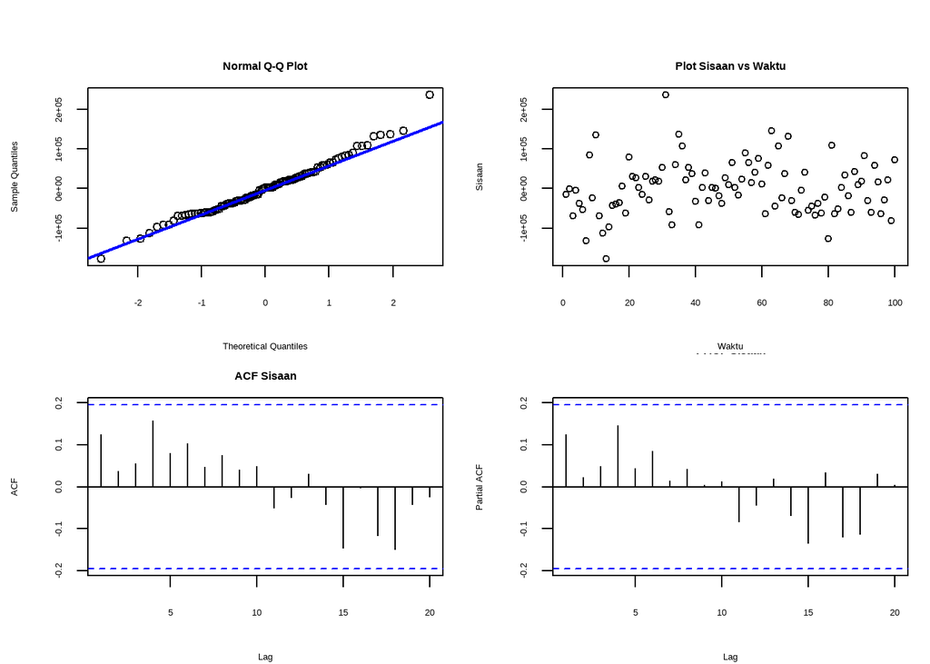

```r
# Sisaan dari model
sisaan <- model4$residuals

par(mfrow = c(2,2),
    mar = c(4,4,2,1),
    oma = c(0,0,2,0))

# Q-Q Plot (normalitas)
qqnorm(sisaan, main = "Normal Q-Q Plot")
qqline(sisaan, col = "blue", lwd = 2)

# Sisaan vs Waktu
plot(sisaan, type = "p",
     main = "Plot Sisaan vs Waktu",
     xlab = "Waktu", ylab = "Sisaan")

# ACF sisaan
acf(sisaan, main = "ACF Sisaan")

# PACF sisaan
pacf(sisaan, main = "PACF Sisaan")
```

Dari Q-Q Plot:

- Titik-titik residual mengikuti garis diagonal.
- Hanya ada sedikit deviasi di bagian ekor.  
  → Residual mendekati distribusi normal.

Dari Plot Sisaan vs Waktu:

- Sisaan menyebar acak di sekitar garis nol.
- Tidak terlihat pola tertentu (tren atau musiman).  
  → Residual bersifat acak (white noise).

Dari ACF Sisaan:

- Hampir semua lag berada dalam batas kepercayaan.
- Tidak ada autokorelasi signifikan yang tersisa.  
  → Menunjukkan residual tidak berkorelasi.

Dari PACF Sisaan:

- Hampir semua lag juga dalam batas kepercayaan.
- Tidak ada pola autokorelasi parsial yang kuat.  
  → Menguatkan bahwa residual white noise.

## Uji Formal

```r
#1) Sisaan Menyebar Normal
ks.test(sisaan,"pnorm")
```

```
##
##  Asymptotic one-sample Kolmogorov-Smirnov test
##
## data:  sisaan
## D = 0.51, p-value < 2.2e-16
## alternative hypothesis: two-sided
```

**1. Uji Normalitas (Kolmogorov–Smirnov):**  
- $H_0$: Sisaan berdistribusi normal  
- $H_1$: Sisaan tidak berdistribusi normal  
- Hasil: $D = 0.51$, $p\text{-value} < 2.2 \times 10^{-16}$  
- Karena $p\text{-value} < 0.05$, maka $H_0$ ditolak.  
- Interpretasi: Secara formal sisaan tidak normal. Namun, dari Q-Q plot terlihat bahwa sisaan masih mendekati distribusi normal dengan deviasi kecil pada ekor.

```r
#2) Sisaan saling bebas/tidak ada autokorelasi
Box.test(sisaan, type = "Ljung")
```

```
##
##  Box-Ljung test
##
## data:  sisaan
## X-squared = 1.5805, df = 1, p-value = 0.2087
```

**2. Uji Autokorelasi (Box–Ljung Test pada sisaan):**  
- $H_0$: Tidak ada autokorelasi pada sisaan (white noise)  
- $H_1$: Ada autokorelasi pada sisaan  
- Hasil: $\chi^2 = 1.5805$, $df = 1$, $p\text{-value} = 0.2087$  
- Karena $p\text{-value} > 0.05$, maka $H_0$ diterima.  
- Interpretasi: Sisaan tidak memiliki autokorelasi, sehingga memenuhi asumsi independensi.

```r
#3) Sisaan homogen
Box.test((sisaan)^2, type = "Ljung")
```

```
##
##  Box-Ljung test
##
## data:  (sisaan)^2
## X-squared = 0.80456, df = 1, p-value = 0.3697
```

**3. Uji Heteroskedastisitas (Box–Ljung Test pada kuadrat sisaan):**  
- $H_0$: Tidak ada autokorelasi pada kuadrat sisaan (ragam konstan / homoskedastis)  
- $H_1$: Ada autokorelasi pada kuadrat sisaan (heteroskedastisitas)  
- Hasil: $\chi^2 = 0.80456$, $df = 1$, $p\text{-value} = 0.3697$  
- Karena $p\text{-value} > 0.05$, maka $H_0$ diterima.  
- Interpretasi: Sisaan tidak menunjukkan gejala heteroskedastisitas, sehingga ragam dapat dianggap konstan.

```r
#4) Nilai tengah sisaan sama dengan nol
t.test(sisaan, mu = 0, conf.level = 0.95)
```

```
##
##  One Sample t-test
##
## data:  sisaan
## t = 0.067931, df = 99, p-value = 0.946
## alternative hypothesis: true mean is not equal to 0
## 95 percent confidence interval:
##  -12831.86  13741.63
## sample estimates:
## mean of x
##  454.8819
```

**4. Uji Rataan Nol (One Sample t-test):**  
- $H_0$: $\mu_{\text{sisaan}} = 0$  
- $H_1$: $\mu_{\text{sisaan}} \neq 0$  
- Hasil: $t = 0.0679$, $df = 99$, $p\text{-value} = 0.946$  
- Karena $p\text{-value} > 0.05$, maka $H_0$ diterima.  
- Interval kepercayaan 95%: $(-12831.86 , 13741.63)$ mencakup 0.  
- Interpretasi: Rataan sisaan tidak berbeda signifikan dari nol.

**Kesimpulan umum:**  
- Normalitas: ditolak secara formal, tetapi Q-Q plot menunjukkan mendekati normal.  
- Autokorelasi: tidak ada (white noise).  
- Heteroskedastisitas: tidak ada (ragam konstan).  
- Rataan nol: terpenuhi.

# Overfitting

Tahapan selanjutnya adalah overfitting dilakukan dengan menaikkan orde AR($p$) dan MA($q$) dari model ARIMA(2,0,2). Kandidat model overfitting adalah ARIMA(3,0,2), ARIMA(2,0,3), dan ARIMA(3,0,3). Berdasarkan perbandingan nilai AIC dan BIC, model hasil overfitting tidak memberikan perbaikan yang berarti dibandingkan model tentatif. Oleh karena itu, model terbaik yang dipilih tetap ARIMA(2,0,2) dan akan digunakan pada tahap peramalan.

```r
# Overfitting models
model_over1 <- Arima(train, order=c(3,0,2), method="ML")
model_over2 <- Arima(train, order=c(2,0,3), method="ML")
model_over3 <- Arima(train, order=c(3,0,3), method="ML")
```

## Ringkasan AIC

```r
# Tabel perbandingan AIC & BIC
overfitting_models <- data.frame(
  Model = c("ARIMA(2,0,2)", "ARIMA(3,0,2)",
            "ARIMA(2,0,3)", "ARIMA(3,0,3)"),
  AIC = c(AIC(model4), AIC(model_over1),
          AIC(model_over2), AIC(model_over3)),
  BIC = c(BIC(model4), BIC(model_over1),
          BIC(model_over2), BIC(model_over3))
)

overfitting_models
```

| Model | AIC | BIC |
| --- | --- | --- |
| ARIMA(2,0,2) | 2523.512 | 2539.143 |
| ARIMA(3,0,2) | 2523.170 | 2541.406 |
| ARIMA(2,0,3) | 2523.513 | 2541.749 |
| ARIMA(3,0,3) | 2527.511 | 2548.352 |

Meskipun ARIMA(3,0,2) memiliki AIC paling kecil, model ARIMA(2,0,2) dipilih sebagai model terbaik karena:

- Memberikan nilai BIC paling kecil,
- Lebih sederhana (parsimonious),
- Hasil overfitting tidak meningkatkan performa secara berarti.  
  → Model ARIMA(2,0,2) digunakan untuk tahap peramalan.

# Peramalan

```r
# Forecast sepanjang test
ramalan <- forecast::forecast(model4, h = length(test))

# Ambil nilai ramalan
hasil <- ramalan$mean

# Bandingkan aktual vs forecast
perbandingan <- cbind(
  Aktual   = as.numeric(test),
  Forecast = as.numeric(hasil)
)
print(head(perbandingan, 10))
```

```
##         Aktual Forecast
##  [1,] 278776.4 234635.8
##  [2,] 278776.4 254782.9
##  [3,] 251824.9 265854.5
##  [4,] 214769.9 262351.5
##  [5,] 171320.8 249282.7
##  [6,] 462236.4 236938.7
##  [7,] 203285.4 233211.0
##  [8,] 203285.4 238909.0
##  [9,] 265070.4 248561.5
## [10,] 265070.4 255150.5
```

```r
# Hitung akurasi (MAPE, RMSE, dll)
akurasi_test <- accuracy(hasil, test)
akurasi_test
```

```
##                ME     RMSE      MAE       MPE    MAPE
## Test set 7113.734 73740.96 55251.39 -4.278708 21.7582
```

## Plot Data Aktual vs Forecast

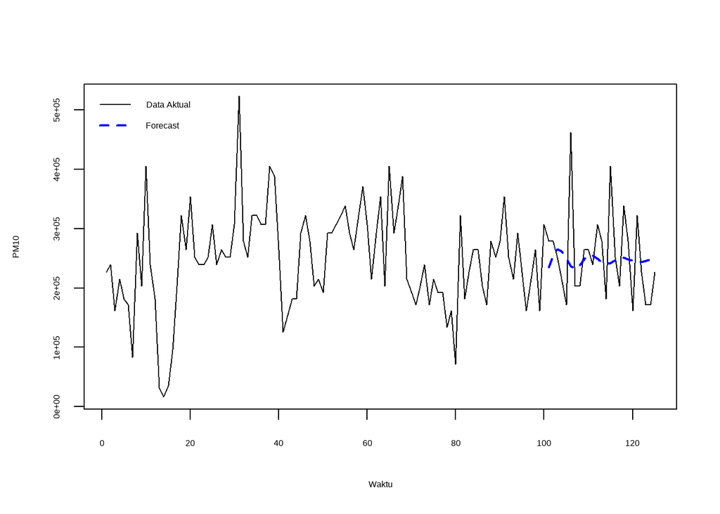

```r
# Plot train + test
ts.plot(c(train, test), col="black", lty=1,
        xlab="Waktu", ylab="PM10")

# Tambahkan garis forecast
lines((length(train)+1):(length(train)+length(test)),
      hasil, col="blue", lty=2, lwd=2)

legend("topleft",
       legend=c("Data Aktual","Forecast"),
       col=c("black","blue"),
       lty=c(1,2), lwd=c(1,2), bty="n")
```